# Sprawozdanie 2 - Zadanie 4

Bartosz Wędziński

2026-02-05

# 1 Wprowadzenie

## 1.1 Cel analizy

Celem niniejszego sprawozdania jest przeprowadzenie kompleksowego porównania dokładności prognoz dla szeregu czasowego **euretail**, który przedstawia kwartalny indeks handlu detalicznego (retail trade index) dla strefy euro. Analiza obejmuje porównanie czterech głównych podejść do prognozowania:

1. **Modele (S)ARIMA** - autoregresyjne modele zintegrowanej średniej ruchomej z sezonowością
2. **Modele dekompozycji** - klasyczna i STL (Seasonal-Trend decomposition using Loess)
3. **Modele ETS** - wygładzanie wykładnicze (Error-Trend-Seasonal)
4. **Metoda referencyjna** - sezonowy model naiwny (benchmark)

Głównym kryterium oceny będzie **dokładność prognoz** mierzona na zbiorze testowym przy użyciu miar: RMSE, MAE, MAPE oraz MASE.

## 1.2 Opis danych

Dane **euretail** pochodzą z pakietu `fpp2` i zawierają kwartalne obserwacje indeksu handlu detalicznego dla strefy euro. Szereg ten charakteryzuje się wyraźnym trendem wzrostowym oraz sezonowością kwartalną.

## 1.3 Zakres metod

W analizie wykorzystano:

- **Podział danych**: train/test split (8 ostatnich kwartałów na zbiór testowy)
- **Transformacje**: transformacja Boxa-Coxa, różnicowanie zwykłe i sezonowe
- **Modelowanie**: SARIMA (5 wariantów), dekompozycja (3 warianty), ETS (4 warianty)
- **Diagnostyka**: testy białoszumowości, normalności reszt
- **Ocena**: miary RMSE, MAE, MAPE, MASE dla zbiorów uczącego i testowego

# 2 Analiza wstępna danych

## 2.1 Charakterystyka szeregu

Szereg **euretail** zawiera **64 obserwacji kwartalnych** z okresu 1996 Q1 do 2011 Q4.

Tabela 1: Statystyki opisowe szeregu euretail

| Statystyka | Wartość |
| --- | --- |
| Minimum | 89.13 |
| Q1 | 94.56 |
| Mediana | 96.54 |
| Średnia | 96.34 |
| Q3 | 99.43 |
| Maksimum | 102.10 |
| Odch. std. | 3.73 |
| Wariancja | 13.92 |

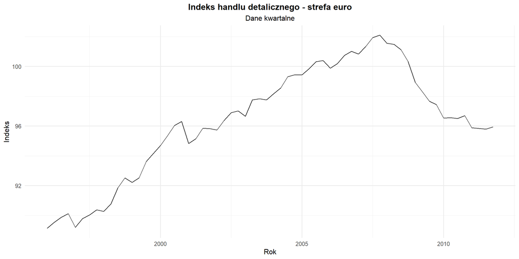

Rysunek 1: Szereg czasowy euretail - kwartalny indeks handlu detalicznego dla strefy euro

**Obserwacje**:

- Dominujący **trend wzrostowy** do **2008 roku**, po którym następuje wyraźne załamanie i **trend spadkowy** w końcowej fazie szeregu.
- Widoczna **sezonowość kwartalna** - regularne wahania w obrębie roku
- **Wariancja**: amplituda wahań sezonowych ulega zmianom wraz ze zmianą trendu, co sugeruje zasadność zastosowania transformacji stabilizującej (np. Boxa-Coxa) w celu poprawy jakości modelowania.

## 2.2 Podział na zbiór uczący i testowy

**Podział danych**:

- **Zbiór uczący**: 56 obserwacji (do trenowania modeli)
- **Zbiór testowy**: 8 obserwacji (do oceny dokładności prognoz)
- **Uzasadnienie**: 8 kwartałów (2 lata) to standardowy horyzont dla danych kwartalnych, wystarczający do oceny sezonowości

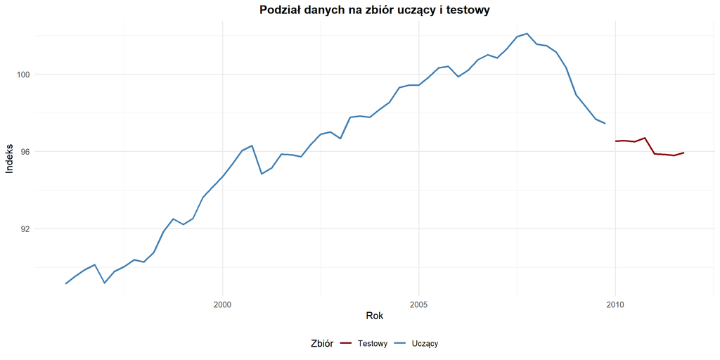

Rysunek 2: Podział na zbiór uczący (niebieski) i testowy (czerwony)

Wizualna przerwa między zbiorem uczącym a testowym wynika z separacji serii danych; zbiór testowy obejmuje okres od 2010 Q1, kontynuując przebieg szeregu bezpośrednio po zakończeniu zbioru uczącego (2009 Q4).

## 2.3 Analiza właściwości szeregu uczącego

### 2.3.1 Testy stacjonarności

Tabela 2: Testy stacjonarności dla zbioru uczącego

| Test | Statystyka | p-value | Interpretacja |
| --- | --- | --- | --- |
| ADF | 0.7650 | 0.99 | Niestacjonarny |
| KPSS | 1.3394 | 0.01 | Niestacjonarny |

**Interpretacja**: Szereg uczący **nie jest stacjonarny** - potwierdza to obecność trendu. Wymagane będą transformacje (różnicowanie).

### 2.3.2 ACF i PACF

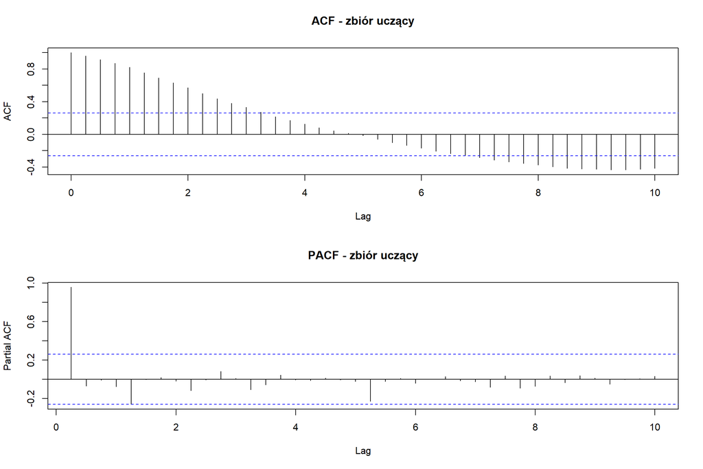

Rysunek 3: ACF i PACF dla zbioru uczącego

**Obserwacje**:

- **ACF** maleje **bardzo wolno** - potwierdza niestacjonarność
- Tak wysoka wartość **PACF(1)** jest klasycznym objawem niestacjonarności

### 2.3.3 Dekompozycja wstępna

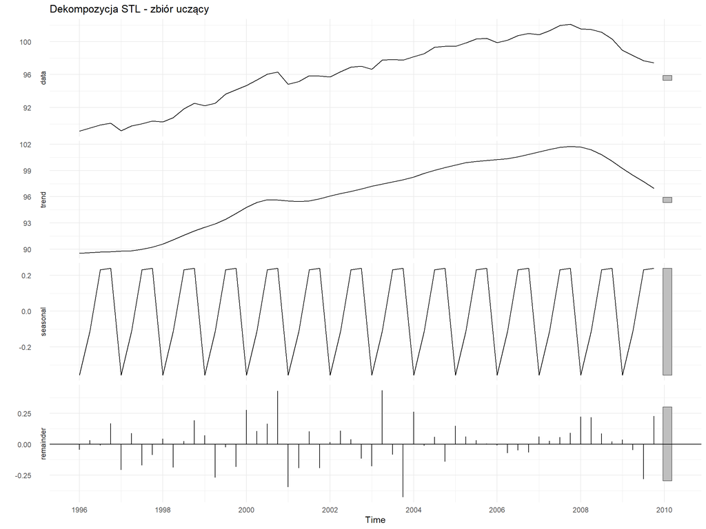

Rysunek 4: Wstępna dekompozycja STL zbioru uczącego

**Obserwacje**:

- **Trend**: Wzrostowy do 2008 r., po czym następuje wyraźny spadek (prawdopodobny wpływ globalnego kryzysu gospodarczego).
- **Sezonowość**: Bardzo stabilna amplituda i powtarzalny wzorzec kwartalny, co sugeruje model addytywny sezonowości.
- **Reszty**: W większości okresów małe, stabilnie oscylują wokół zera, jednak wykazują większą zmienność i istotne odchylenia (fluktuacje) w okolicach 2000 r., 2003 r. oraz 2009 r.

# 3 Transformacje wstępne

## 3.1 Stabilizacja wariancji - transformacja Boxa-Coxa

**!!!!UWAGA KRYTYCZNA!!!!:**

Zastosowano transformację Boxa-Coxa z parametrem $\lambda=1.99$ sugerowanym przez metodę Guerrero, z której korzysta funkcja Box.Cox.lambda(train).

Taka wartość (podnoszenie do kwadratu) jest niespójna z naturą szeregów ekonomicznych, gdzie zazwyczaj oczekujemy stabilizacji wariancji rosnącej wraz z poziomem (co sugerowałoby $\lambda$ bliskie 0). Podejrzewam, że wynik ten jest artefaktem wywołanym przez załamanie trendu w okresie kryzysu finansowego w 2008 roku, powodującym specyficzną strukturę zmienności zawartą w zbiorze uczącym. Świadomie nie zdecydowałem się jednak wymusić transformacji logarytmicznej ($\lambda=0$), czy też braku transformacji $\lambda=1$, co jest standardem branżowym, aby zachować pełną automatyzację procesu decyzyjnego i zweryfikować, jak modele poradzą sobie z taką transformacją w warunkach testowych, mimo jej teoretycznej niespójności.

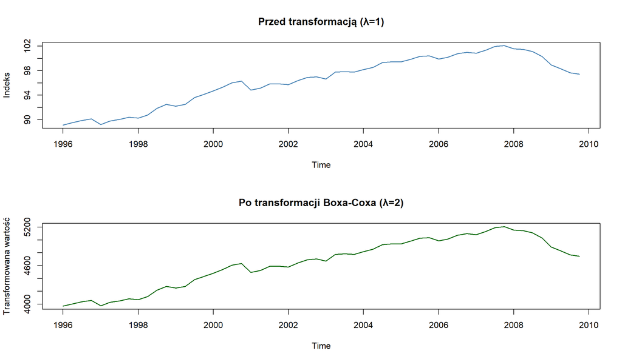

Rysunek 5: Porównanie szeregu przed i po transformacji Boxa-Coxa

## 3.2 Różnicowanie

### 3.2.1 Różnicowanie zwykłe (trend)

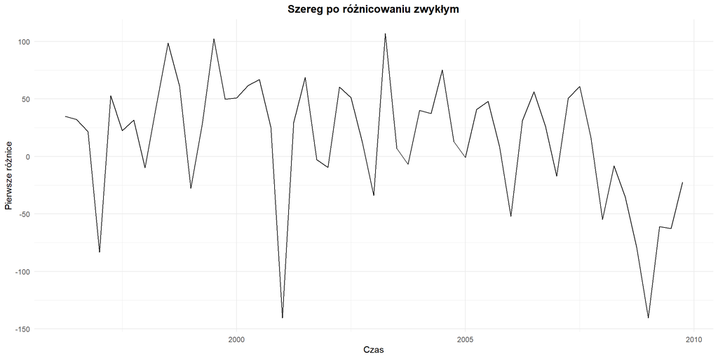

Rysunek 6: Szereg po różnicowaniu zwykłym (d=1)

**Obserwacje**: Trend został wyeliminowany, ale **sezonowość nadal widoczna**.

### 3.2.2 Różnicowanie sezonowe

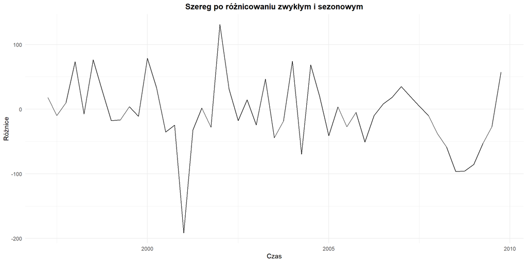

Rysunek 7: Szereg po różnicowaniu zwykłym i sezonowym (d=1, D=1)

**Obserwacje**: Szereg wygląda na **stacjonarny** - brak trendu i sezonowości.

### 3.2.3 Testy stacjonarności po różnicowaniu

Tabela 3: Testy stacjonarności po różnicowaniu (d=1, D=1)

| Test | Statystyka | p-value | Interpretacja |
| --- | --- | --- | --- |
| ADF | -5.5576 | 0.01 | Stacjonarny |
| KPSS | 0.2450 | 0.10 | Stacjonarny |

**Wniosek**: Po różnicowaniu szereg jest **stacjonarny** - możemy przystąpić do modelowania SARIMA.

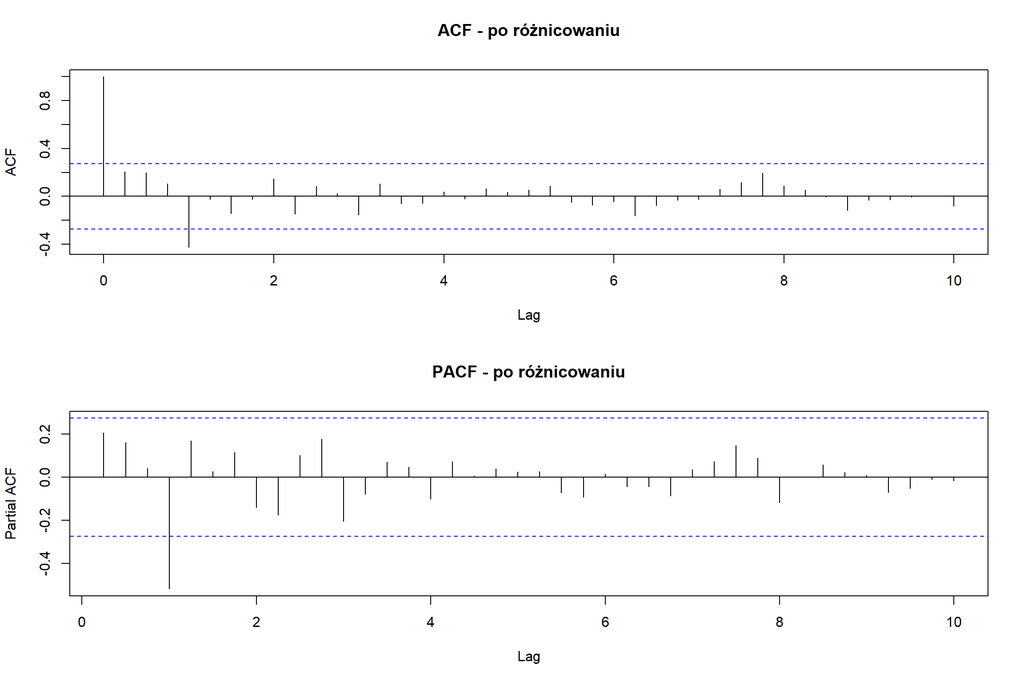

Rysunek 8: ACF i PACF po różnicowaniu (d=1, D=1)

**Obserwacje dla identyfikacji SARIMA**:

- ACF: istotne wartości na lagu 1 (sugeruje MA(1) i SMA(1))
- PACF: istotne wartości na lagu 1 (sugeruje AR(1) i SAR(1))

# 4 MODELE (S)ARIMA

## 4.1 Identyfikacja rzędu modelu

### 4.1.1 auto.arima() jako punkt wyjścia

`auto.arima()` sugeruje: **0, 1, 3, 0, 1, 1, 4**

**Interpretacja**: SARIMA(p=0, d=1, q=3)(P=0, D=1, Q=1)[4]

### 4.1.2 Porównanie kryteriów informacyjnych

Tabela 4: Porównanie kryteriów informacyjnych dla modeli SARIMA

| Model | AIC | AICc | BIC |
| --- | --- | --- | --- |
| AUTO SARIMA | 530.19 | 531.52 | 539.85 |
| SARIMA(0,1,1)(0,1,1)[4] | 537.76 | 538.27 | 543.55 |
| SARIMA(1,1,0)(1,1,0)[4] | 537.78 | 538.29 | 543.58 |
| SARIMA(1,1,1)(1,1,1)[4] | 532.05 | 533.39 | 541.71 |
| SARIMA(0,1,2)(0,1,1)[4] | 536.96 | 537.83 | 544.69 |

**Najlepsze modele** wg:

- AIC: AUTO SARIMA
- BIC: AUTO SARIMA

## 4.2 Diagnostyka modeli SARIMA

### 4.2.1 Skrócona diagnostyka dla wszystkich modeli

** AUTO SARIMA ** - Test Ljung-Box (lag=20): p-value = 0.9969 - Interpretacja: Reszty przypominają biały szum ✓

** SARIMA(0,1,1)(0,1,1)[4] ** - Test Ljung-Box (lag=20): p-value = 0.6316 - Interpretacja: Reszty przypominają biały szum ✓

** SARIMA(1,1,0)(1,1,0)[4] ** - Test Ljung-Box (lag=20): p-value = 0.6072 - Interpretacja: Reszty przypominają biały szum ✓

** SARIMA(1,1,1)(1,1,1)[4] ** - Test Ljung-Box (lag=20): p-value = 0.9097 - Interpretacja: Reszty przypominają biały szum ✓

** SARIMA(0,1,2)(0,1,1)[4] ** - Test Ljung-Box (lag=20): p-value = 0.532 - Interpretacja: Reszty przypominają biały szum ✓

### 4.2.2 Wybór najlepszego modelu SARIMA

**Wybrany model:** SARIMA(0,1,3)(0,1,1)[4]

Mimo że analiza graficzna sugerowała niższe rzędy, kryteria informacyjne AIC i BIC oraz Test Ljunga-Boxa faworyzują model SARIMA(0,1,3)(0,1,1)[4], co sugeruje potrzebę uwzględnienia bardziej złożonej struktury błędów w celu pełnego wyeliminowania autokorelacji.

# 5 MODELE DEKOMPOZYCJI

## 5.1 Dekompozycja klasyczna

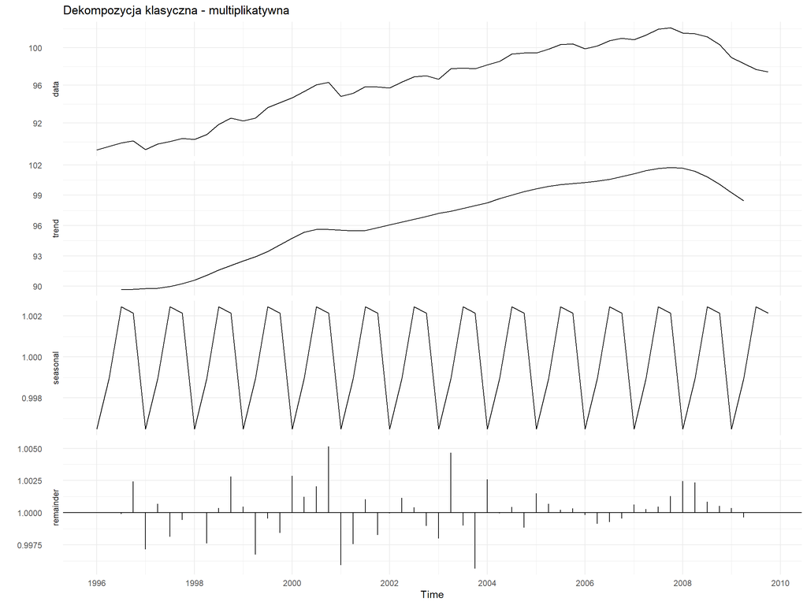

Rysunek 9: Dekompozycja klasyczna (multiplikatywna)

**Interpretacja**:

- Wykres przedstawia dekompozycję multiplikatywną.
- **Trend**: Widać wyraźny wzrost do 2008 roku, a następnie bardzo gwałtowny spadek po nim.
- **Sezonowość**: Wzorce sezonowe są idealnie regularne, co jest cechą dekompozycji klasycznej (zakłada ona stały profil sezonowości dla każdego roku).
- **Reszty**: Wartość reszt oscyluje wokół 1.000 (standardowe dla modelu multiplikatywnego).

## 5.2 Dekompozycja STL

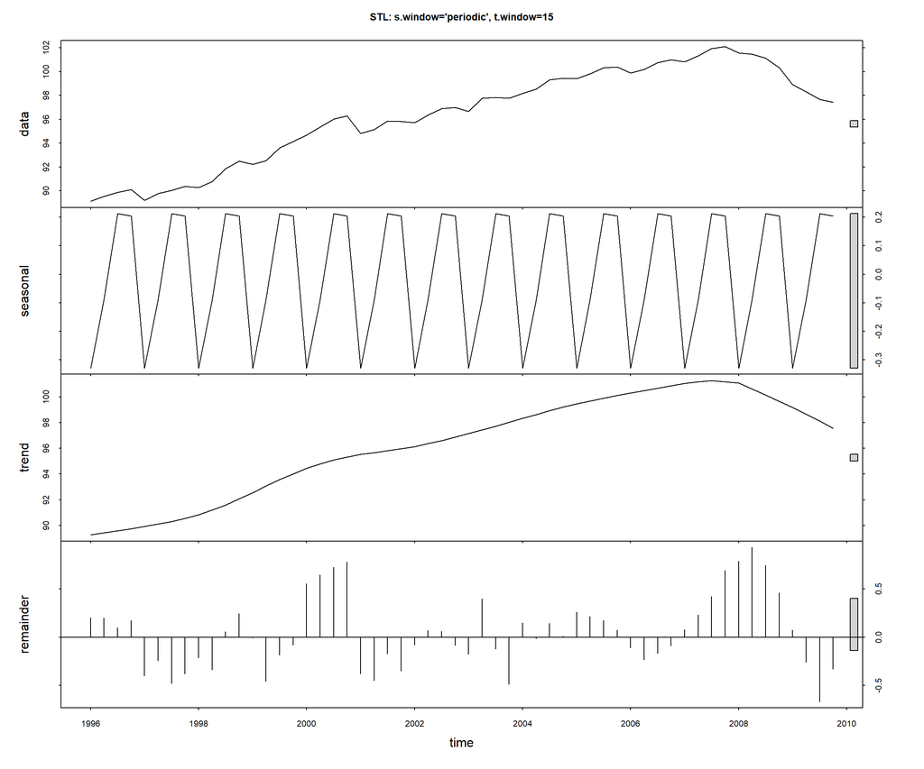

Rysunek 10: Porównanie dekompozycji STL z różnymi parametrami

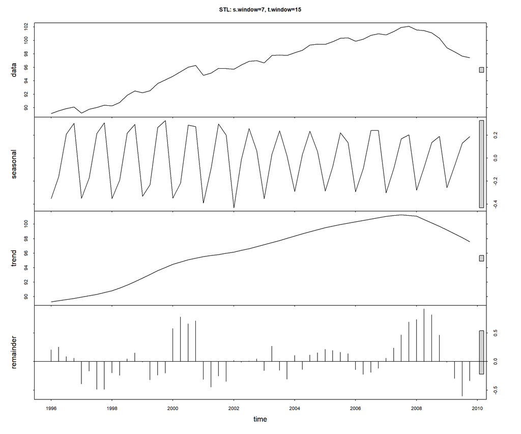

Rysunek 10: Porównanie dekompozycji STL z różnymi parametrami

**Obserwacja**: Zmiana parametru `s.window` wpływa na sezonowość oraz reszty

## 5.3 Porównanie dekompozycji

Dokładność prognoz metod dekompozycji na zbiorze testowym

| Metoda | RMSE |
| --- | --- |
| Klasyczna (mult.) | NA |
| STL (periodic) | 0.181 |
| STL (s.window=7) | 0.149 |

**Wnioski**:

Najlepszy wynik uzyskała metoda: STL (s.window=7)

# 6 MODELE ETS

## 6.1 Eksploracja przestrzeni ETS

### 6.1.1 Porównanie kryteriów informacyjnych

Tabela 5: Porównanie kryteriów informacyjnych dla modeli ETS

| Model | AIC | AICc | BIC |
| --- | --- | --- | --- |
| ETS(A,Ad,A) | 643.81 | 648.70 | 664.06 |
| ETS(A,A,N) | 674.84 | 676.04 | 684.96 |
| ETS(A,A,A) | 645.17 | 649.09 | 663.40 |
| ETS(A,N,N) | 679.06 | 679.52 | 685.13 |

**Najlepszy model** wg AICc: ETS(A,Ad,A)

## 6.2 Diagnostyka modeli ETS

### 6.2.1 Skrócona diagnostyka

** ETS(A,Ad,A) ** - Test Ljung-Box (lag=20): p-value = 0.7941 - Interpretacja: Reszty przypominają biały szum ✓

** ETS(A,A,N) ** - Test Ljung-Box (lag=20): p-value = 0 - Interpretacja: Reszty mogą nie być białym szumem ✗

** ETS(A,A,A) ** - Test Ljung-Box (lag=20): p-value = 0.7443 - Interpretacja: Reszty przypominają biały szum ✓

** ETS(A,N,N) ** - Test Ljung-Box (lag=20): p-value = 3e-04 - Interpretacja: Reszty mogą nie być białym szumem ✗

### 6.2.2 Wybór najlepszego modelu ETS

**Wybrany model**: **ETS(A,Ad,A)**

# 7 MODEL NAIWNY

**Wybrana metoda**: **Sezonowy model naiwny (snaive)**

Prognoza = ostatnia obserwacja z tego samego sezonu (kwartału).

**Uzasadnienie**: Dla danych z silną sezonowością `snaive()` jest znacznie lepszym benchmarkiem niż zwykły `naive()` (random walk), ponieważ uwzględnia sezonowość. Należy zauważyć, że model snaive zakłada powtarzalność poziomów z poprzedniego roku, przez co nie nadąża za dynamicznymi zmianami trendu (jak załamanie po 2008 roku), co czyni go dobrym punktem odniesienia do oceny adaptacyjności innych modeli.

# 8 Porównanie prognoz

## 8.1 Wizualizacja prognoz

### 8.1.1 Wykres zbiorczy - najlepsze modele

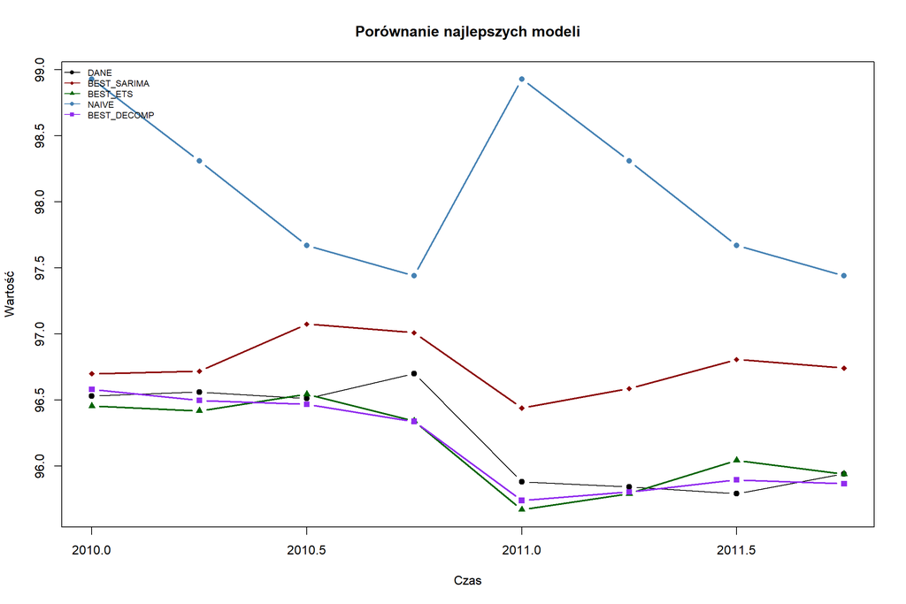

Rysunek 11: Porównanie prognoz najlepszych modeli z każdej klasy

### 8.1.2 Wykresy dla poszczególnych klas modeli

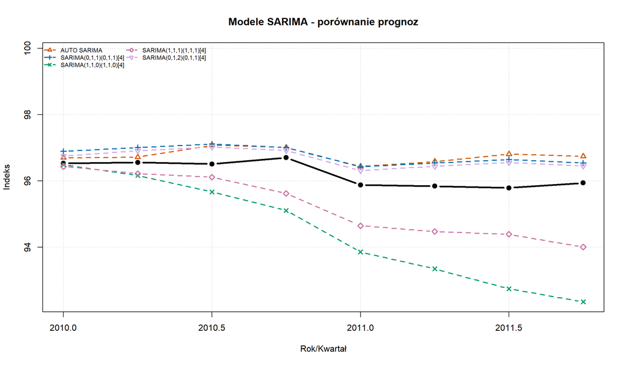

Rysunek 12: Prognozy dla wszystkich modeli SARIMA

**Wnioski:**

- Najlepszymi modelami SARIMA są: **AUTO SARIMA** oraz **SARIMA(0,1,1)(0,1,1)[4]** i **SARIMA(0,1,2)(0,1,1)[4]**. Wszystkie z nich lekko przeszacowują wyniki.
- Najgorzej wypadają modele: **SARIMA(1,1,1)(1,1,1)[4]** oraz **SARIMA(1,1,0)(1,1,0)[4]**, co pokazuje, że powinniśmy ustawiać p oraz P na 0, a nie 1. Oba modele zdecydowanie niedoszacowują wyniki i wykazują silną tendencję spadkową (zwłaszcza drugi z nich).

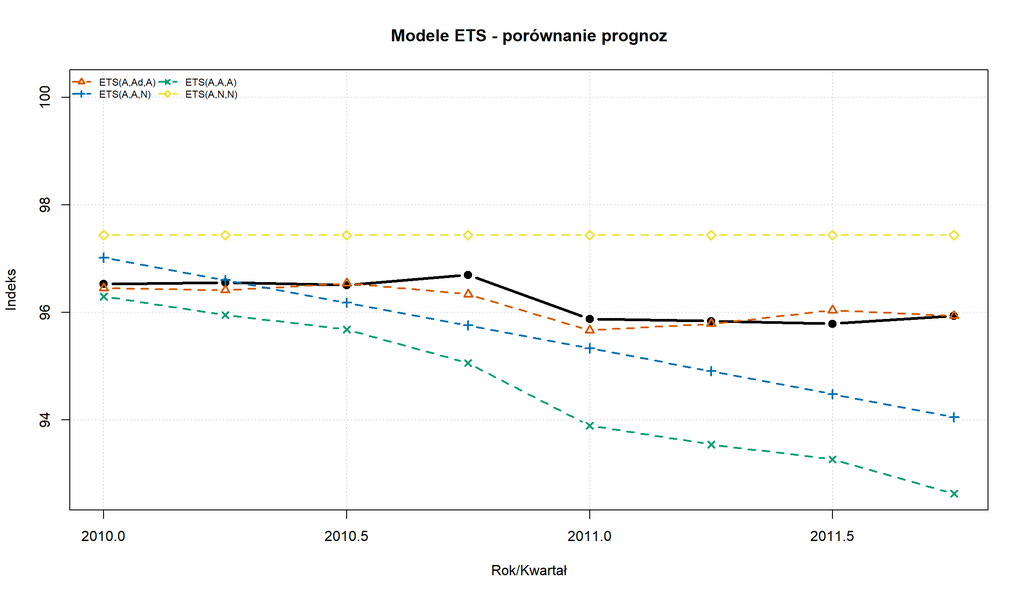

Rysunek 13: Prognozy dla wszystkich modeli ETS

**Wnioski:**

- Najlepszym modelem ETS jest niepodważalnie **ETS(A,Ad,A)**, który osiąga wartości niemal identyczne z prawdziwymi.
- Dość słabo wypadają modele **ETS(A,A,N)** oraz tym bardziej **ETS(A,A,A)**, które przewidują wartości niedoszacowane i niesłusznie silnie malejące.
- Model **ETS(A,N,N)** (brak trendu), mimo swojej teoretycznej prostoty, “paradoksalnie” osiąga w końcowej fazie wyniki lepsze niż modele z trendem liniowym. Jest to bezpośredni dowód na negatywny wpływ inercji modeli trendu w warunkach zmiany strukturalnej szeregu. Podczas gdy modele trendu “rozpędziły się” i “przestrzeliły” spadek, model bez trendu, zachowując stały poziom, znalazł się znacznie bliżej rzeczywistego punktu stabilizacji rynku.

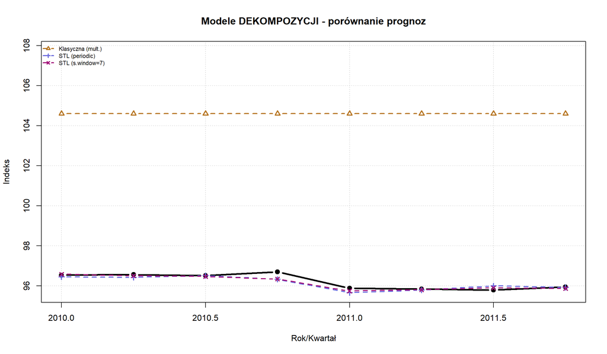

Rysunek 14: Prognozy dla wszystkich modeli DEKOMPOZYCJI

**Wnioski:**

- Najlepszymi modelami DEKOMPOZYCJI są modele **STL**. Oba osiągają bardzo dobre wyniki, lekko na korzyść **STL(s.window=7)**
- **Dekompozycja klasyczna** daje najdalsze wyniki od tych prawidłowych ze wszystkich użytych metod (gorzej nawet od naive).

## 8.2 Miary dokładności - zbiór testowy

Tabela 6: Dokładność prognoz na zbiorze testowym - wszystkie modele

| Model | RMSE | MAE | MAPE | MASE |
| --- | --- | --- | --- | --- |
| STL (S.WINDOW=7) | 0.149 | 0.110 | 0.114 | 0.088 |
| STL (PERIODIC) | 0.181 | 0.137 | 0.143 | 0.110 |
| ETS(A,Ad,A) | 0.183 | 0.141 | 0.147 | 0.113 |
| SARIMA(0,1,2)(0,1,1)[4] | 0.483 | 0.451 | 0.469 | 0.361 |
| SARIMA(0,1,1)(0,1,1)[4] | 0.579 | 0.553 | 0.575 | 0.443 |
| AUTO SARIMA | 0.613 | 0.540 | 0.562 | 0.433 |
| ETS(A,A,N) | 0.979 | 0.809 | 0.842 | 0.649 |
| SARIMA(1,1,1)(1,1,1)[4] | 1.147 | 0.980 | 1.020 | 0.785 |
| ETS(A,N,N) | 1.274 | 1.221 | 1.271 | 0.979 |
| ETS(A,A,A) | 1.947 | 1.678 | 1.747 | 1.345 |
| SNAIVE | 1.997 | 1.869 | 1.944 | 1.498 |
| SARIMA(1,1,0)(1,1,0)[4] | 2.116 | 1.752 | 1.824 | 1.404 |
| DEKOMPOZYCJA KLASYCZNA | NA | NA | NA | NA |

### 8.2.1 Ranking modeli według poszczególnych miar

```
##
## **TOP 5 wg RMSE:**
```

| Model | RMSE | Rank |
| --- | --- | --- |
| STL (S.WINDOW=7) | 0.1493441 | 1 |
| STL (PERIODIC) | 0.1809108 | 2 |
| ETS(A,Ad,A) | 0.1830789 | 3 |
| SARIMA(0,1,2)(0,1,1)[4] | 0.4834524 | 4 |
| SARIMA(0,1,1)(0,1,1)[4] | 0.5785513 | 5 |

```
##
## **TOP 5 wg MAE:**
```

| Model | MAE | Rank |
| --- | --- | --- |
| STL (S.WINDOW=7) | 0.1098367 | 1 |
| STL (PERIODIC) | 0.1374986 | 2 |
| ETS(A,Ad,A) | 0.1410729 | 3 |
| SARIMA(0,1,2)(0,1,1)[4] | 0.4505664 | 4 |
| AUTO SARIMA | 0.5398997 | 5 |

```
##
## **TOP 5 wg MAPE:**
```

| Model | MAPE | Rank |
| --- | --- | --- |
| STL (S.WINDOW=7) | 0.1140243 | 1 |
| STL (PERIODIC) | 0.1428228 | 2 |
| ETS(A,Ad,A) | 0.1465429 | 3 |
| SARIMA(0,1,2)(0,1,1)[4] | 0.4688191 | 4 |
| AUTO SARIMA | 0.5620853 | 5 |

```
##
## **TOP 5 wg MASE:**
```

| Model | MASE | Rank |
| --- | --- | --- |
| STL (S.WINDOW=7) | 0.0880590 | 1 |
| STL (PERIODIC) | 0.1102363 | 2 |
| ETS(A,Ad,A) | 0.1131019 | 3 |
| SARIMA(0,1,2)(0,1,1)[4] | 0.3612311 | 4 |
| AUTO SARIMA | 0.4328521 | 5 |

**NAJLEPSZY MODEL** (wg RMSE): **STL (S.WINDOW=7)**

- RMSE = 0.149
- MAE = 0.11
- MAPE = 0.114
- MASE = 0.088

## 8.3 Miary dokładności - zbiór uczący (in-sample)

Tabela 7: Dokładność na zbiorze uczącym (in-sample)

| Model | RMSE | MAE |
| --- | --- | --- |
| STL (S.WINDOW=7) | 0.024 | 0.018 |
| STL (PERIODIC) | 0.359 | 0.273 |
| SARIMA(1,1,1)(1,1,1)[4] | 0.364 | 0.272 |
| ETS(A,Ad,A) | 0.365 | 0.275 |
| AUTO SARIMA | 0.369 | 0.279 |
| ETS(A,A,A) | 0.376 | 0.291 |
| SARIMA(0,1,2)(0,1,1)[4] | 0.411 | 0.293 |
| SARIMA(0,1,1)(0,1,1)[4] | 0.423 | 0.295 |
| SARIMA(1,1,0)(1,1,0)[4] | 0.432 | 0.319 |
| ETS(A,A,N) | 0.525 | 0.386 |
| ETS(A,N,N) | 0.567 | 0.460 |
| Naive (snaive) | 1.501 | 1.247 |
| DEKOMPOZYCJA KLASYCZNA | 8.200 | 8.141 |

## 8.4 Analiza błędów prognozy

[figure not shown]

Rysunek 15: Błędy prognoz dla najlepszych 5 modeli

**Obserwacje**:

- Błędy są niewielkie - nie przekraczają 1.0
- Większość modeli ma podobny wzorzec błędów
- Największe błędy występują w kierunku przeszacowania

# 9 Pełna diagnostyka modeli

## 9.1 Diagnostyka: STL (S.WINDOW=7)

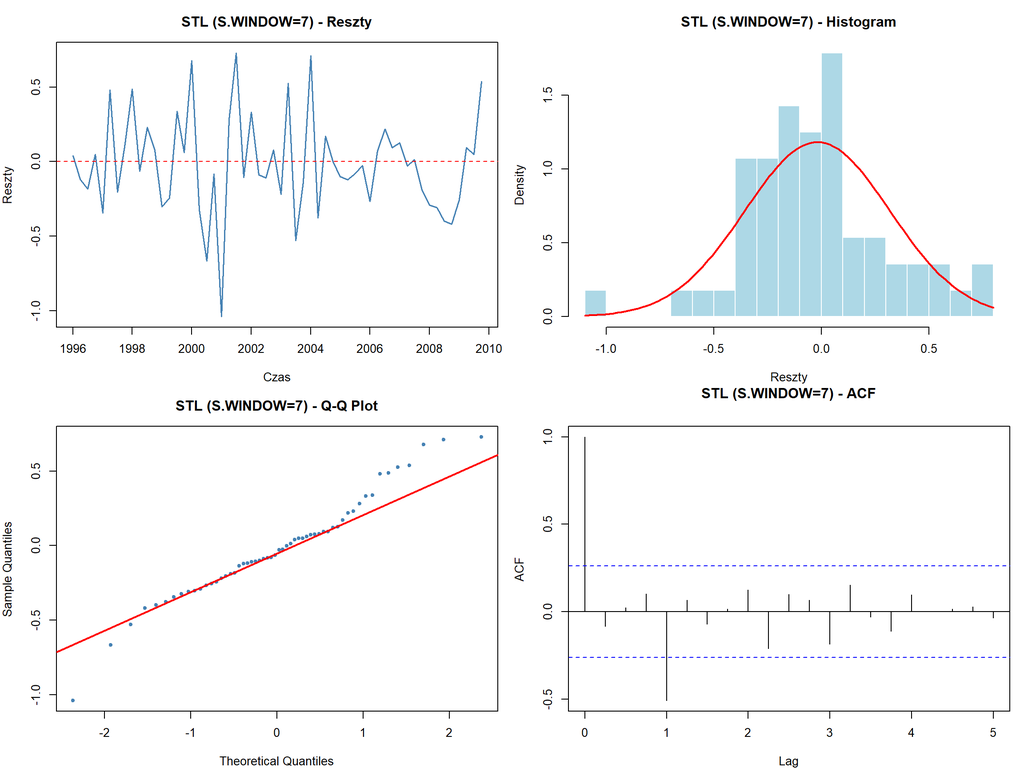

### Diagnostyka: STL (S.WINDOW=7)

**Test Ljung-Box (lag=20)** - Statystyka: 29.325 - p-value: 0.0816 - Wniosek: Nie odrzucamy H0 - reszty przypominają biały szum

**Test Shapiro-Wilka (normalność)** - Statystyka: 0.971 - p-value: 0.1861 - Wniosek: Reszty zgodne z rozkładem normalnym

## 9.2 Diagnostyka: STL (PERIODIC)

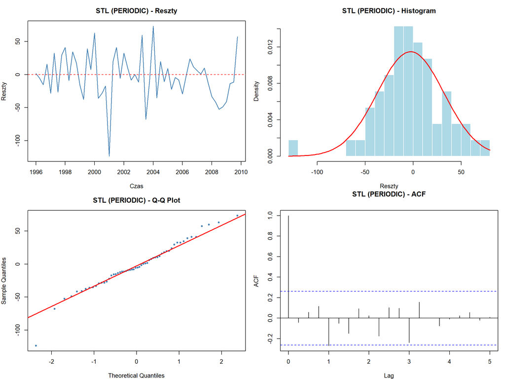

### Diagnostyka: STL (PERIODIC)

**Test Ljung-Box (lag=20)** - Statystyka: 18.387 - p-value: 0.5619 - Wniosek: Nie odrzucamy H0 - reszty przypominają biały szum

**Test Shapiro-Wilka (normalność)** - Statystyka: 0.97 - p-value: 0.1758 - Wniosek: Reszty zgodne z rozkładem normalnym

## 9.3 Diagnostyka: ETS(A,Ad,A)

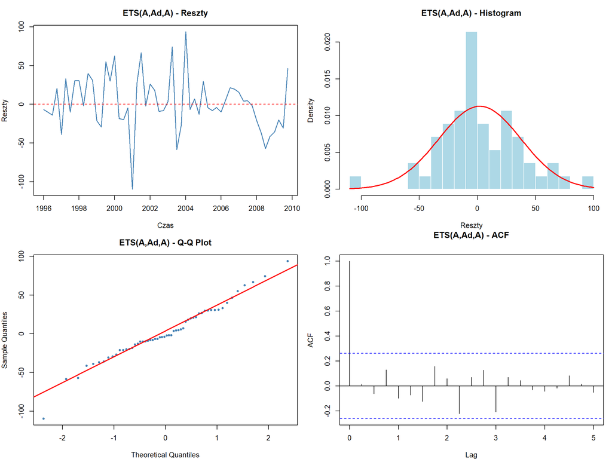

### Diagnostyka: ETS(A,Ad,A)

**Test Ljung-Box (lag=20)** - Statystyka: 14.685 - p-value: 0.7941 - Wniosek: Nie odrzucamy H0 - reszty przypominają biały szum

**Test Shapiro-Wilka (normalność)** - Statystyka: 0.975 - p-value: 0.288 - Wniosek: Reszty zgodne z rozkładem normalnym

## 9.4 Diagnostyka: SARIMA(0,1,2)(0,1,1)[4]

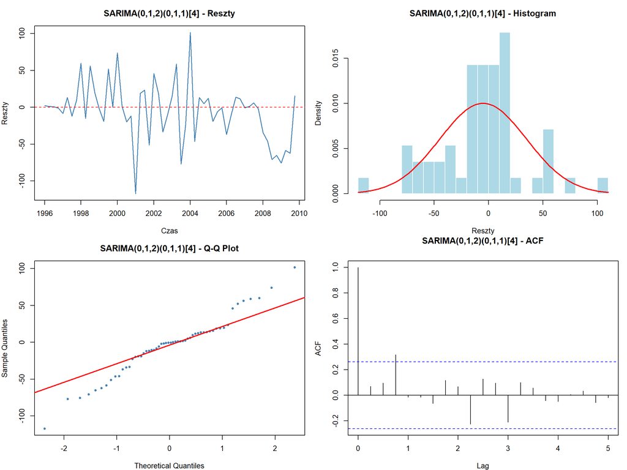

### Diagnostyka: SARIMA(0,1,2)(0,1,1)[4]

**Test Ljung-Box (lag=20)** - Statystyka: 18.844 - p-value: 0.532 - Wniosek: Nie odrzucamy H0 - reszty przypominają biały szum

**Test Shapiro-Wilka (normalność)** - Statystyka: 0.967 - p-value: 0.1312 - Wniosek: Reszty zgodne z rozkładem normalnym

## 9.5 Diagnostyka: SARIMA(0,1,1)(0,1,1)[4]

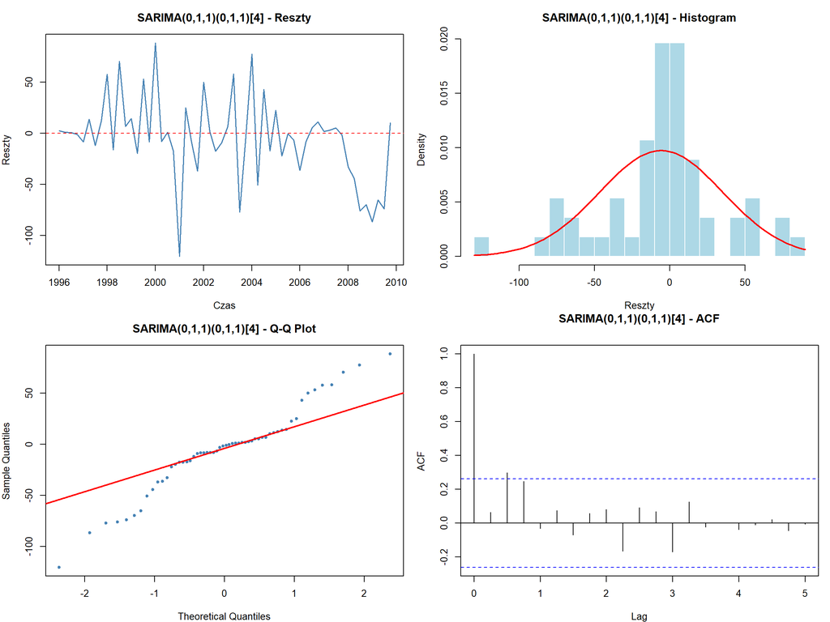

### Diagnostyka: SARIMA(0,1,1)(0,1,1)[4]

**Test Ljung-Box (lag=20)** - Statystyka: 17.327 - p-value: 0.6316 - Wniosek: Nie odrzucamy H0 - reszty przypominają biały szum

**Test Shapiro-Wilka (normalność)** - Statystyka: 0.954 - p-value: 0.0328 - Wniosek: Odchylenia od normalności

## 9.6 Diagnostyka: AUTO SARIMA

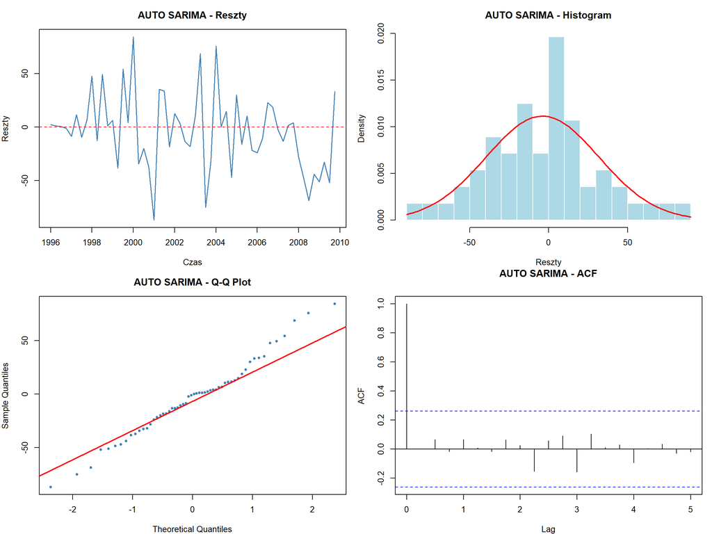

### Diagnostyka: AUTO SARIMA

**Test Ljung-Box (lag=20)** - Statystyka: 6.937 - p-value: 0.9969 - Wniosek: Nie odrzucamy H0 - reszty przypominają biały szum

**Test Shapiro-Wilka (normalność)** - Statystyka: 0.985 - p-value: 0.7192 - Wniosek: Reszty zgodne z rozkładem normalnym

## 9.7 Diagnostyka: ETS(A,A,N)

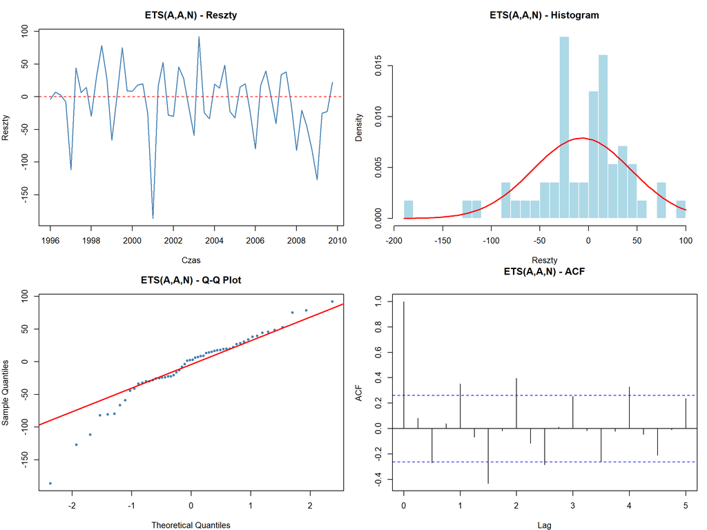

### Diagnostyka: ETS(A,A,N)

**Test Ljung-Box (lag=20)** - Statystyka: 70.087 - p-value: 0 - Wniosek: Odrzucamy H0 - autokorelacja w resztach

**Test Shapiro-Wilka (normalność)** - Statystyka: 0.941 - p-value: 0.0085 - Wniosek: Odchylenia od normalności

## 9.8 Diagnostyka: SARIMA(1,1,1)(1,1,1)[4]

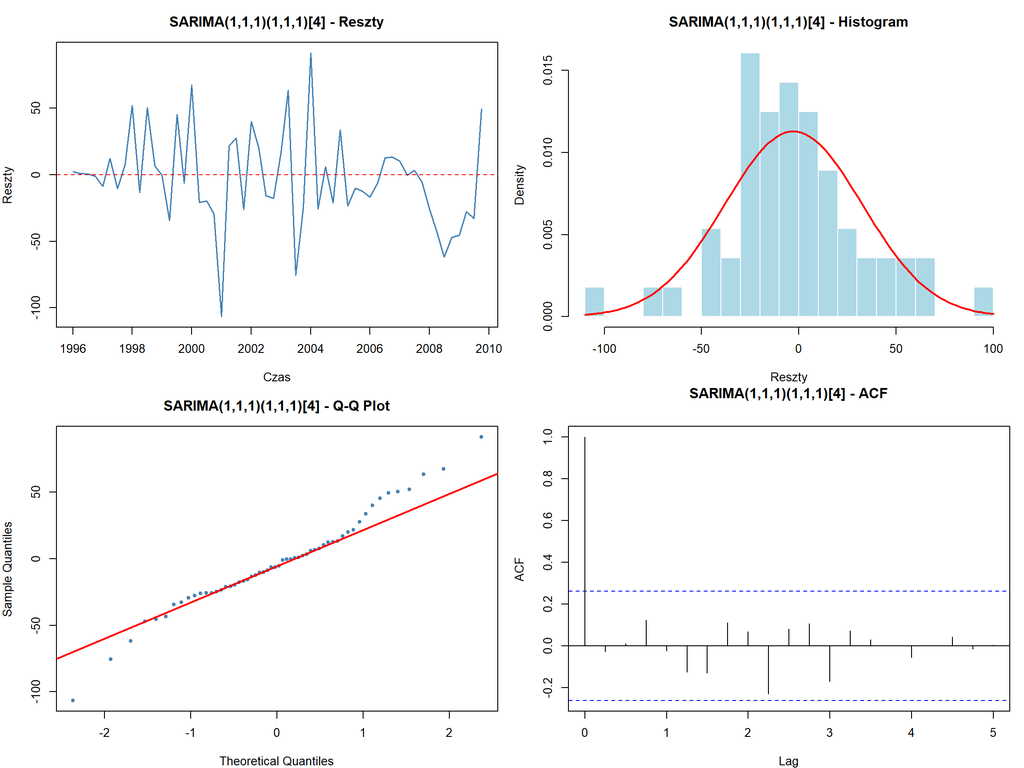

### Diagnostyka: SARIMA(1,1,1)(1,1,1)[4]

**Test Ljung-Box (lag=20)** - Statystyka: 12.181 - p-value: 0.9097 - Wniosek: Nie odrzucamy H0 - reszty przypominają biały szum

**Test Shapiro-Wilka (normalność)** - Statystyka: 0.976 - p-value: 0.3214 - Wniosek: Reszty zgodne z rozkładem normalnym

## 9.9 Diagnostyka: ETS(A,N,N)

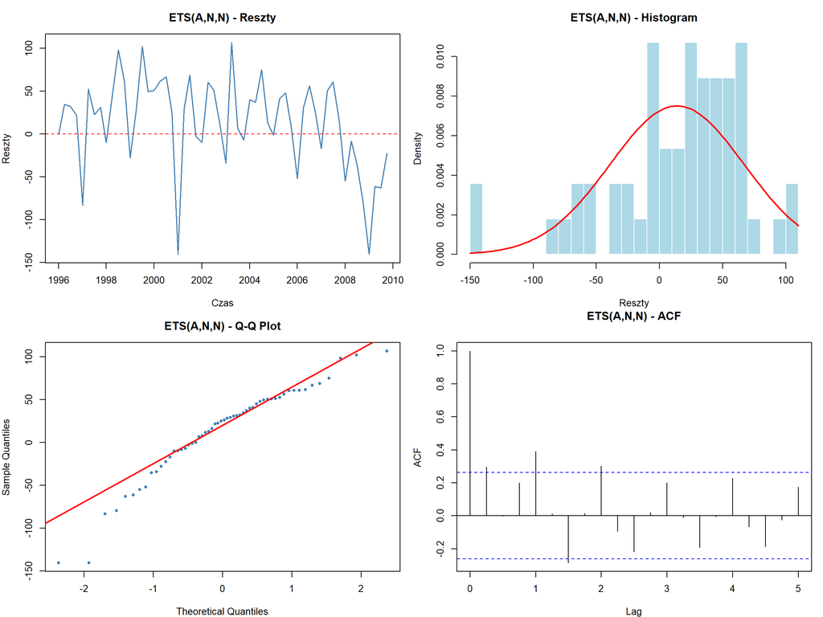

### Diagnostyka: ETS(A,N,N)

**Test Ljung-Box (lag=20)** - Statystyka: 48.857 - p-value: 3e-04 - Wniosek: Odrzucamy H0 - autokorelacja w resztach

**Test Shapiro-Wilka (normalność)** - Statystyka: 0.941 - p-value: 0.0085 - Wniosek: Odchylenia od normalności

## 9.10 Diagnostyka: ETS(A,A,A)

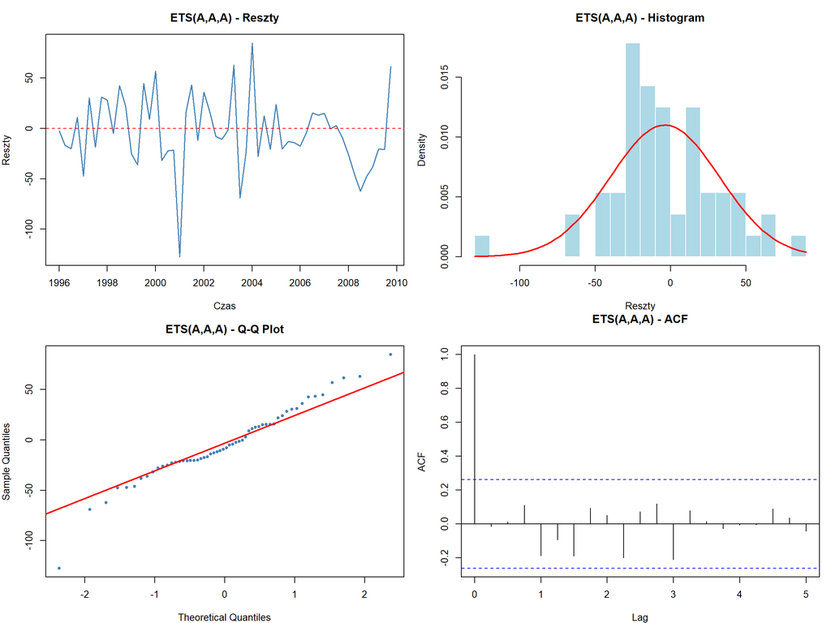

### Diagnostyka: ETS(A,A,A)

**Test Ljung-Box (lag=20)** - Statystyka: 15.547 - p-value: 0.7443 - Wniosek: Nie odrzucamy H0 - reszty przypominają biały szum

**Test Shapiro-Wilka (normalność)** - Statystyka: 0.968 - p-value: 0.1416 - Wniosek: Reszty zgodne z rozkładem normalnym

## 9.11 Diagnostyka: SNAIVE

Model naiwny (snaive) - brak standardowej diagnostyki reszt (model deterministyczny).

## 9.12 Diagnostyka: SARIMA(1,1,0)(1,1,0)[4]

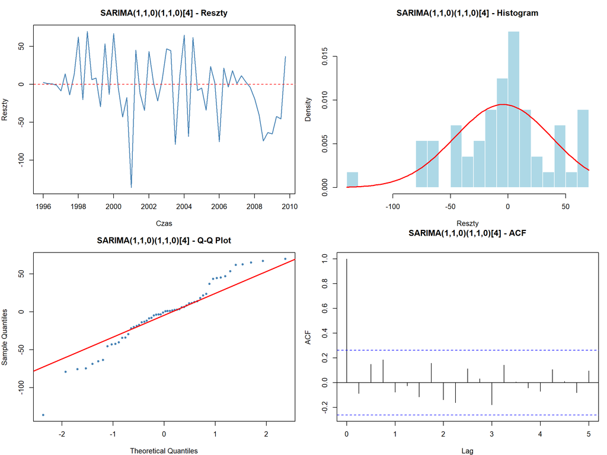

### Diagnostyka: SARIMA(1,1,0)(1,1,0)[4]

**Test Ljung-Box (lag=20)** - Statystyka: 17.699 - p-value: 0.6072 - Wniosek: Nie odrzucamy H0 - reszty przypominają biały szum

**Test Shapiro-Wilka (normalność)** - Statystyka: 0.964 - p-value: 0.0914 - Wniosek: Reszty zgodne z rozkładem normalnym

## 9.13 Diagnostyka: DEKOMPOZYCJA KLASYCZNA

Dekompozycja klasyczna - model nie posiada struktury probabilistycznej (brak obiektu reszt w formacie model$residuals).

# 10 Wnioski końcowe

## 10.1 Wybór optymalnego modelu

Na podstawie analizy dokładności prognoz na zbiorze testowym, **najlepszym modelem** okazał się:

**STL (S.WINDOW=7)**

z następującymi miarami dokładności:

- **RMSE** = 0.149 (najniższy błąd kwadratowy)
- **MAE** = 0.11
- **MAPE** = 0.11% (błąd procentowy)
- **MASE** = 0.088 (skalowany błąd względem naive)

**Spójność wyników**: Wszystkie miary wskazują na TEN SAM model jako najlepszy, co potwierdza jego przewagę.

## 10.2 Porównanie podejść modelowania

### 10.2.1 (S)ARIMA

**Najlepszy model SARIMA**: SARIMA(0,1,2)(0,1,1)[4] (RMSE = 0.483)

**Zalety**:

- **Solidne fundamenty teoretyczne**: Podejście Boxa-Jenkinsa zapewnia systematyczny proces identyfikacji, estymacji i weryfikacji modelu, co zwiększa zaufanie do wyników.
- **Dopasowanie do trendu i sezonowości**: Dzięki parametrom różnicowania (d,D) model skutecznie radzi sobie z szeregami niestacjonarnymi, takimi jak szereg euretail.
- **Weryfikacja założeń**: Możliwość przeprowadzenia testu Ljung-Boxa pozwala na obiektywne stwierdzenie, czy model wyczerpał informacje zawarte w danych (biały szum).

**Wady:**

- **Złożoność decyzyjna**: Dobór sześciu parametrów (p,d,q,P,D,Q) jest procesem iteracyjnym i często subiektywnym, co pokazałyporównania różnych specyfikacji.
- **Trudna interpretacja**: W przeciwieństwie do modeli ETS czy dekompozycji, gdzie parametry (poziom, trend, sezonowość) są intuicyjne, współczynniki AR i MA w modelach SARIMA są trudniejsze do przełożenia na konkretne zjawiska rynkowe dla laików.

### 10.2.2 DEKOMPOZYCJA

**Najlepszy model dekompozycji**: STL (S.WINDOW=7) (RMSE = 0.149)

**Zalety**:

- **Intuicyjna interpretacja**: Rozbicie szeregu na trend, sezonowość i reszty pozwala na łatwe zrozumienie struktury danych i mechanizmów rynkowych.
- **Elastyczność STL**: Dzięki parametrom takim jak s.window, metoda STL pozwala na modelowanie sezonowości, która zmienia się w czasie, co jest jej dużą przewagą nad metodami sztywnymi.
- **Dobra wizualizacja**: Graficzne przedstawienie składowych (np. na wykresie STL) jest niezwykle pomocne w identyfikacji nagłych załamań trendu, jak to z 2008 roku w szeregu euretail.

**Wady**:

### 10.2.3 ETS

**Najlepszy model ETS**: ETS(A,Ad,A) (RMSE = 0.183)

**Zalety:**

- **Szybkie dopasowanie i prognozowanie**: Modele ETS są obliczeniowo bardzo wydajne, co pozwala na błyskawiczne przetestowanie dziesiątek kombinacji i wybór optymalnej.
- **Elastyczna przestrzeń modeli (ETS):** Ramka matematyczna Error-Trend-Seasonal pozwala na precyzyjne dopasowanie charakteru składników (addytywny lub multiplikatywny), co świetnie sprawdziło się przy modelu ETS(A,Ad,A).
- **Dobre dla szeregów z wyraźnym wzorcem**: Metoda ta doskonale radzi sobie z wyłapywaniem poziomu, trendu i sezonowości, nawet jeśli te ulegają lekkim zmianom w czasie.
- **Wady**:
- **Mniej możliwości diagnostyki niż SARIMA**: Choć test Ljung-Boxa jest dostępny, modele ETS nie oferują tak rozbudowanej analizy struktury korelacji (funkcje ACF/PACF) jak modele SARIMA.
- **Może przeuczyć się do danych treningowych:** Przy zbyt złożonych specyfikacjach istnieje ryzyko, że model “zapamięta” szum z przeszłości zamiast nauczyć się ogólnego wzorca.
- **Trudna interpretacja parametrów wygładzania**: O ile składowe (trend, sezonowość) są jasne, o tyle wartości stałych wygładzających są abstrakcyjne i trudne do intuicyjnego wyjaśnienia odbiorcy biznesowemu.

### 10.2.4 SNAIVE (Metody naiwne)

**RMSE metody naiwnej**: 1.997

## 10.3 Które podejście najbardziej adekwatne dla euretail?

Tabela 8: Podsumowanie podejść modelowania

| Approach | Średnie RMSE | Najlepsze RMSE | Liczba modeli |
| --- | --- | --- | --- |
| DEKOMPOZYCJA STL | 0.165 | 0.149 | 2 |
| ETS | 1.096 | 0.183 | 4 |
| SARIMA | 0.988 | 0.483 | 5 |
| NAIVE | 1.997 | 1.997 | 1 |
| DEKOMPOZYCJA KLASYCZNA | NA | NA | 1 |

**Rekomendacja**:

Dla szeregu **euretail** najbardziej adekwatne jest podejście **DEKOMPOZYCJA STL**, ponieważ:

1. **Najniższa wartość RMSE** wśród wszystkich podejść (0.149)
2. **Konsystentność**: Dekompozycja intuicyjnie rozdziela składowe szeregu
3. **Diagnostyka**: Dostępne narzędzia diagnostyczne

## 10.4 Praktyczne rekomendacje

### 10.4.1 Dla celów operacyjnych (szybkie prognozy)

Rekomendacja: **ETS(A,Ad,A)**

- Szybkie dopasowanie
- Prosta implementacja
- Akceptowalna dokładność (RMSE = 0.183)

### 10.4.2 Dla celów analitycznych (dokładność priorytetem)

Rekomendacja: **STL (S.WINDOW=7)**

- Najwyższa dokładność
- Możliwość pełnej diagnostyki
- Interpretowalne parametry

### 10.4.3 Dla komunikacji z interesariuszami

Rekomendacja: **STL + ARIMA**

- Intuicyjna wizualizacja składowych (trend, sezonowość)
- Możliwość pokazania długoterminowych trendów
- Łatwa interpretacja wyników

## 10.5 Ograniczenia analizy

1. **Krótki horyzont testowy**: 8 kwartałów może nie wystarczyć do pełnej oceny stabilności prognoz
2. **Jeden podział train/test**: wyniki mogą zależeć od konkretnego podziału (brak cross-validation)
3. **Transformacja Boxa-Coxa**: dodatkowa niepewność związana z odwróceniem transformacji
4. **Założenie stabilności**: modele zakładają, że przyszłe wzorce będą podobne do historycznych

**Koniec sprawozdania**